# Projet Modèle de Régression et Test d’Hypothèses

Luweh Adjim Ngarti Exaucé & Laamoumri Yassine

17/12/2020

## Introduction

Dans ce projet, notre but sera d’élaborer un modèle capable d’expliquer la hauteur des vagues en fonction de plusieurs variables explicatives. Dans notre jeu de données, h110d est la variable à expliquer et les autres variables sont les variables explicatives. Etant donnée que nos variables explicatives sont composées de variable quantitatives et qualitatives, notre but est de réaliser une ANCOVA.

Tout d’abord, on convertit nos variables qualitatives saison et direction en variables indicatrices afin de pouvoir mieux manipuler nos données par la suite.

```r
head(vagues)
```

```
##   temperature pression humidite_relative point2rose visibilite_horiz
## 1     21.5875 1012.763            83.375    18.5250           7.5000
## 2      8.7750 1015.275            83.000     6.0500          13.7500
## 3      9.8625 1022.075            86.875     7.7500           8.3125
## 4     13.2750 1011.788            71.500     8.1125          12.2500
## 5     15.4125 1003.962            78.250    11.3125          11.7500
## 6     14.0500 1002.825            85.250    11.4875           8.7500
##   vent_vit_moy vent_vit_rafale vent_dir precipitation_cum    h110d    saison
## 1      18.5200          75.932   247.50         1.4000000 1.381905   Automne
## 2      21.2980          64.820   281.25         0.6400000 6.702083 Printemps
## 3      28.7060          71.302   260.00         3.1666667 3.712353 Printemps
## 4      20.3720          53.708   245.00         0.4666667 3.830000       Ete
## 5      10.1860          53.708   233.75         2.2000000 4.024167       Ete
## 6      20.1405          62.968   260.00         1.6000000 2.663333       Ete
##   direction printemps ete automne hiver est ouest nord sud
## 1     Ouest         0   0       1     0   0     1    0   0
## 2     Ouest         1   0       0     0   0     1    0   0
## 3     Ouest         1   0       0     0   0     1    0   0
## 4     Ouest         0   1       0     0   0     1    0   0
## 5     Ouest         0   1       0     0   0     1    0   0
## 6     Ouest         0   1       0     0   0     1    0   0
```

## Création de notre modèle avec toutes les variables explicatives prises en compte

```r
model <- lm(vagues$h110d~vagues$temperature+vagues$pression+vagues$humidite_relative+vagues$point2rose+vagues$visibilite_horiz+vagues$vent_vit_moy+vagues$vent_vit_rafale+vagues$vent_dir+vagues$precipitation_cum+vagues$saison*vagues$direction)
summary(model)
```

```
##
## Call:
## lm(formula = vagues$h110d ~ vagues$temperature + vagues$pression +
##     vagues$humidite_relative + vagues$point2rose + vagues$visibilite_horiz +
##     vagues$vent_vit_moy + vagues$vent_vit_rafale + vagues$vent_dir +
##     vagues$precipitation_cum + vagues$saison * vagues$direction)
##
## Residuals:
##     Min      1Q  Median      3Q     Max
## -3.5065 -0.5226 -0.0731  0.5002  2.6810
##
## Coefficients:
##                                                Estimate Std. Error t value
## (Intercept)                                  13.5456923  7.0047497   1.934
## vagues$temperature                           -0.0379259  0.0945616  -0.401
## vagues$pression                              -0.0127645  0.0064818  -1.969
## vagues$humidite_relative                      0.0039008  0.0249506   0.156
## vagues$point2rose                             0.0152175  0.0992748   0.153
## vagues$visibilite_horiz                      -0.0019273  0.0035703  -0.540
## vagues$vent_vit_moy                           0.0003062  0.0202003   0.015
## vagues$vent_vit_rafale                        0.0513741  0.0101772   5.048
## vagues$vent_dir                               0.0018972  0.0010927   1.736
## vagues$precipitation_cum                      0.2036125  0.0771378   2.640
## vagues$saisonEte                             -0.5000760  0.2489448  -2.009
## vagues$saisonHiver                            0.2729012  0.2892683   0.943
## vagues$saisonPrintemps                        0.0554792  0.2735362   0.203
## vagues$directionNord                         -0.6607935  0.4182908  -1.580
## vagues$directionOuest                        -0.1650593  0.2777156  -0.594
## vagues$directionSud                          -0.0371601  0.2314016  -0.161
## vagues$saisonEte:vagues$directionNord         0.4398094  0.5957903   0.738
## vagues$saisonHiver:vagues$directionNord       0.2550134  0.5723672   0.446
## vagues$saisonPrintemps:vagues$directionNord   0.1495982  0.6812162   0.220
## vagues$saisonEte:vagues$directionOuest        0.4222981  0.3011588   1.402
## vagues$saisonHiver:vagues$directionOuest      0.9125650  0.3348584   2.725
## vagues$saisonPrintemps:vagues$directionOuest  1.0627244  0.3194397   3.327
## vagues$saisonEte:vagues$directionSud          0.2469202  0.3123983   0.790
## vagues$saisonHiver:vagues$directionSud        0.4249635  0.3133761   1.356
## vagues$saisonPrintemps:vagues$directionSud    0.4996504  0.3172431   1.575
##                                              Pr(>|t|)
## (Intercept)                                  0.053798 .
```

[output cut: 15 more lines]

```
## vagues$saisonEte:vagues$directionNord        0.460801
## vagues$saisonHiver:vagues$directionNord      0.656154
## vagues$saisonPrintemps:vagues$directionNord  0.826284
## vagues$saisonEte:vagues$directionOuest       0.161567
## vagues$saisonHiver:vagues$directionOuest     0.006689 **
## vagues$saisonPrintemps:vagues$directionOuest 0.000954 ***
## vagues$saisonEte:vagues$directionSud         0.429731
## vagues$saisonHiver:vagues$directionSud       0.175788
## vagues$saisonPrintemps:vagues$directionSud   0.116001
## ---
## Signif. codes:  0 '***' 0.001 '**' 0.01 '*' 0.05 '.' 0.1 ' ' 1
##
## Residual standard error: 0.8783 on 428 degrees of freedom
## Multiple R-squared:  0.571,  Adjusted R-squared:  0.547
## F-statistic: 23.74 on 24 and 428 DF,  p-value: < 2.2e-16
```

On visualise la matrice de corrélation  
On voit qu’il y a une forte corrélation positive entre :  
**vent_vit_rafale** et **vent_vit_moy**  
**point2rose** et **temperature**  
**ouest** et **vent_dir**

On constate aussi une forte corrélation négative entre **est** et **vent_dir**

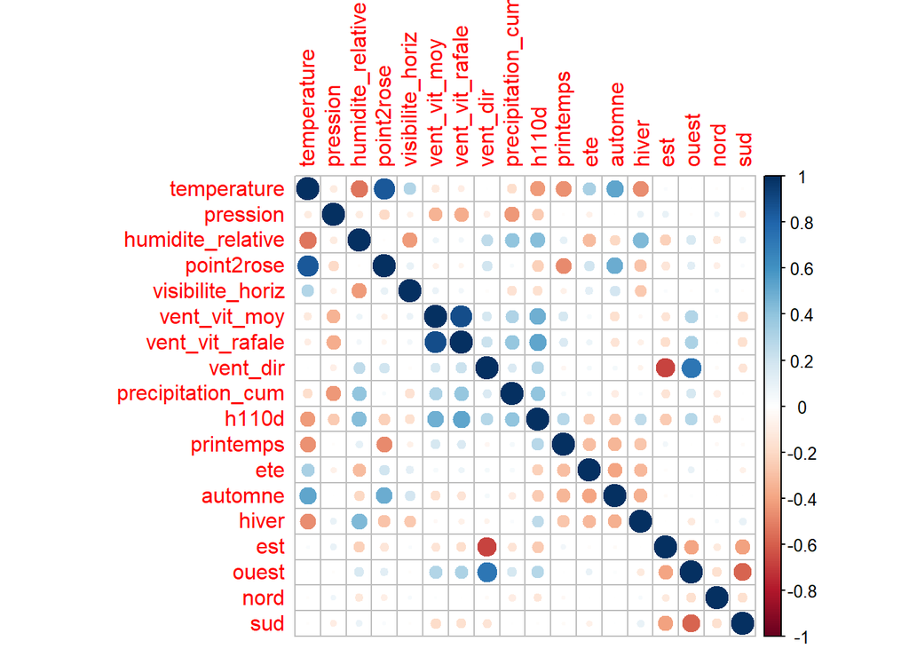

Avant de déterminer un modèle optimal complet, on débute notre étude avec seulement les variables qualitatives afin de voir s’il existe une relation entre les variables qualitatives et la variable à expliquer  
On se retrouve à réaliser une ANOVA à deux facteurs.

```r
model_anova <- lm(data=vagues, h110d~saison*direction)
summary(model_anova)
```

```
##
## Call:
## lm(formula = h110d ~ saison * direction, data = vagues)
##
## Residuals:
##     Min      1Q  Median      3Q     Max
## -2.3860 -0.6377 -0.1484  0.5062  4.6588
##
## Coefficients:
##                                Estimate Std. Error t value Pr(>|t|)
## (Intercept)                     1.27003    0.20269   6.266  8.9e-10 ***
## saisonEte                      -0.24809    0.29547  -0.840 0.401576
## saisonHiver                     0.59929    0.30250   1.981 0.048203 *
## saisonPrintemps                 0.44512    0.29547   1.506 0.132669
## directionNord                  -0.13986    0.47536  -0.294 0.768731
## directionOuest                  0.57320    0.24983   2.294 0.022246 *
## directionSud                    0.25765    0.25067   1.028 0.304582
## saisonEte:directionNord        -0.01625    0.70288  -0.023 0.981563
## saisonHiver:directionNord       0.04821    0.67917   0.071 0.943446
## saisonPrintemps:directionNord  -0.22939    0.80122  -0.286 0.774780
## saisonEte:directionOuest        0.39046    0.35995   1.085 0.278625
## saisonHiver:directionOuest      1.15433    0.39046   2.956 0.003282 **
## saisonPrintemps:directionOuest  1.45747    0.37585   3.878 0.000122 ***
## saisonEte:directionSud          0.17493    0.37288   0.469 0.639198
## saisonHiver:directionSud        0.54969    0.36928   1.489 0.137331
## saisonPrintemps:directionSud    0.70902    0.37772   1.877 0.061167 .
## ---
## Signif. codes:  0 '***' 0.001 '**' 0.01 '*' 0.05 '.' 0.1 ' ' 1
##
## Residual standard error: 1.053 on 437 degrees of freedom
## Multiple R-squared:  0.3702, Adjusted R-squared:  0.3486
## F-statistic: 17.12 on 15 and 437 DF,  p-value: < 2.2e-16
```

On affiche les différents boxplots pour avoir une idée de la relation entre les variables qualitatives et la variable à expliquer

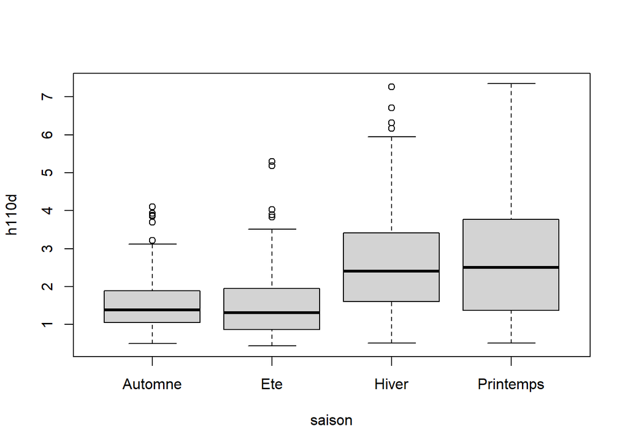

```r
boxplot(data=vagues,h110d~saison)
```

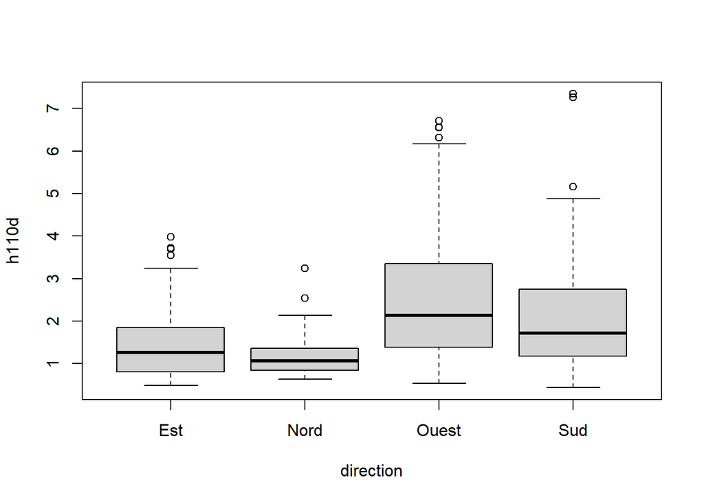

```r
boxplot(data=vagues,h110d~direction)
```

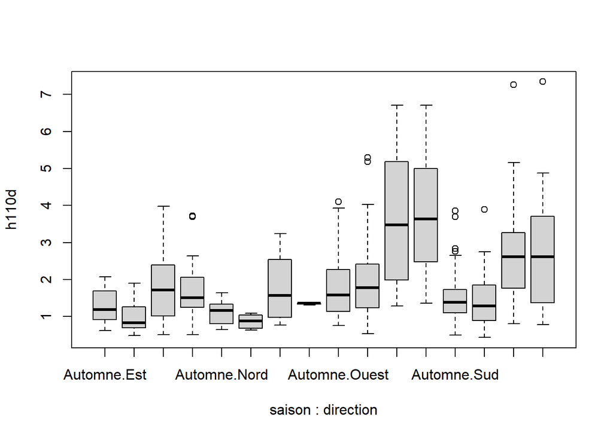

```r
boxplot(data=vagues,h110d~saison*direction)
```

```r
anova(model_anova)
```

```
## Analysis of Variance Table
##
## Response: h110d
##                   Df Sum Sq Mean Sq F value Pr(>F)
## saison             3 149.79  49.931 45.0123 <2e-16 ***
## direction          3 111.11  37.038 33.3888 <2e-16 ***
## saison:direction   9  24.01   2.668  2.4051 0.0114 *
## Residuals        437 484.76   1.109
## ---
## Signif. codes:  0 '***' 0.001 '**' 0.01 '*' 0.05 '.' 0.1 ' ' 1
```

On constate que la p-value de direction et saison ainsi que l’interaction entre ces deux variables est très faible  
Cela veut que dire que l’impact de ces variables est significatif sur la hauteur des vagues

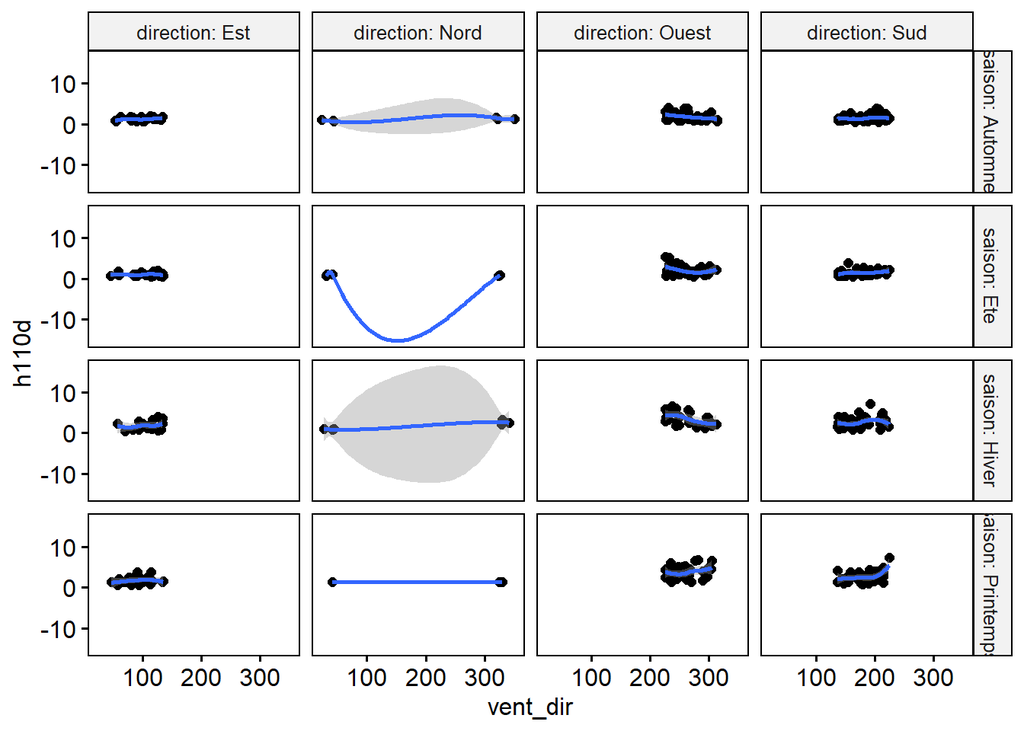

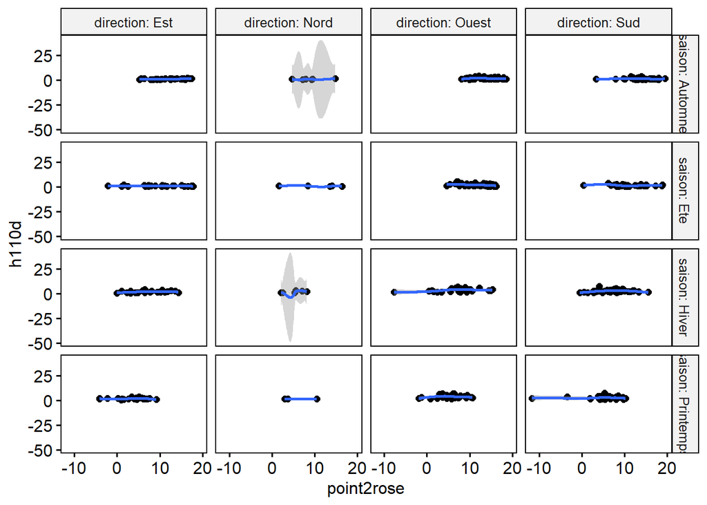

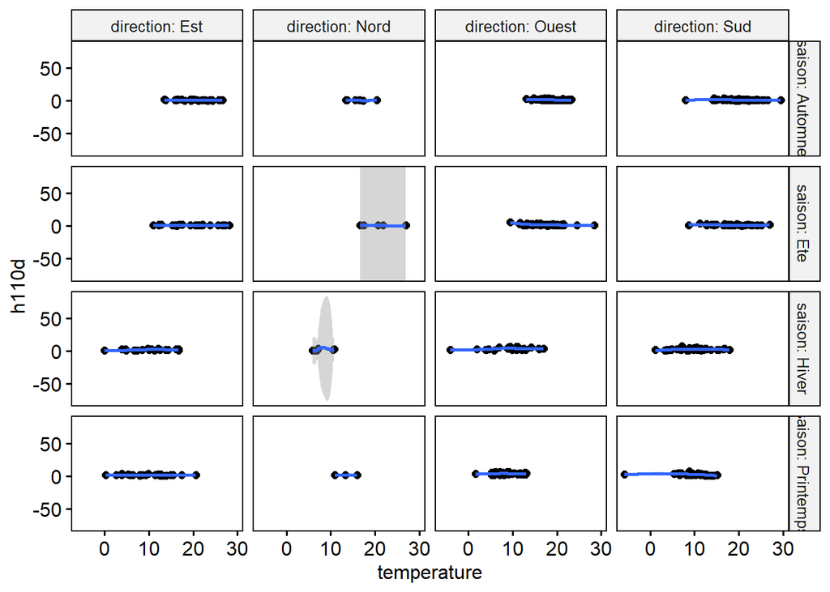

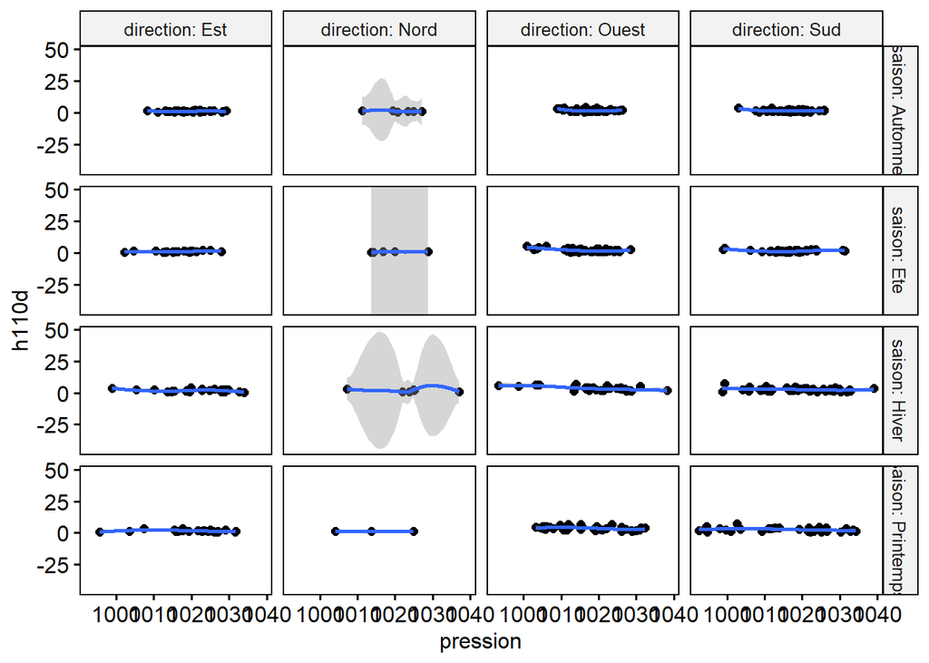

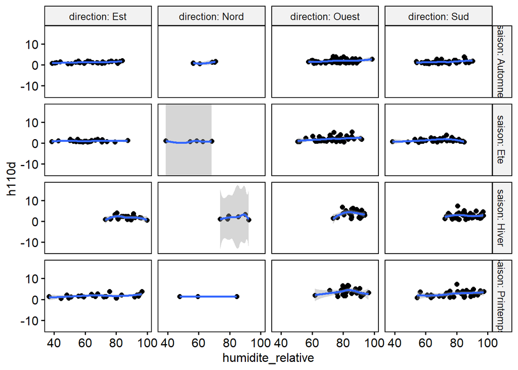

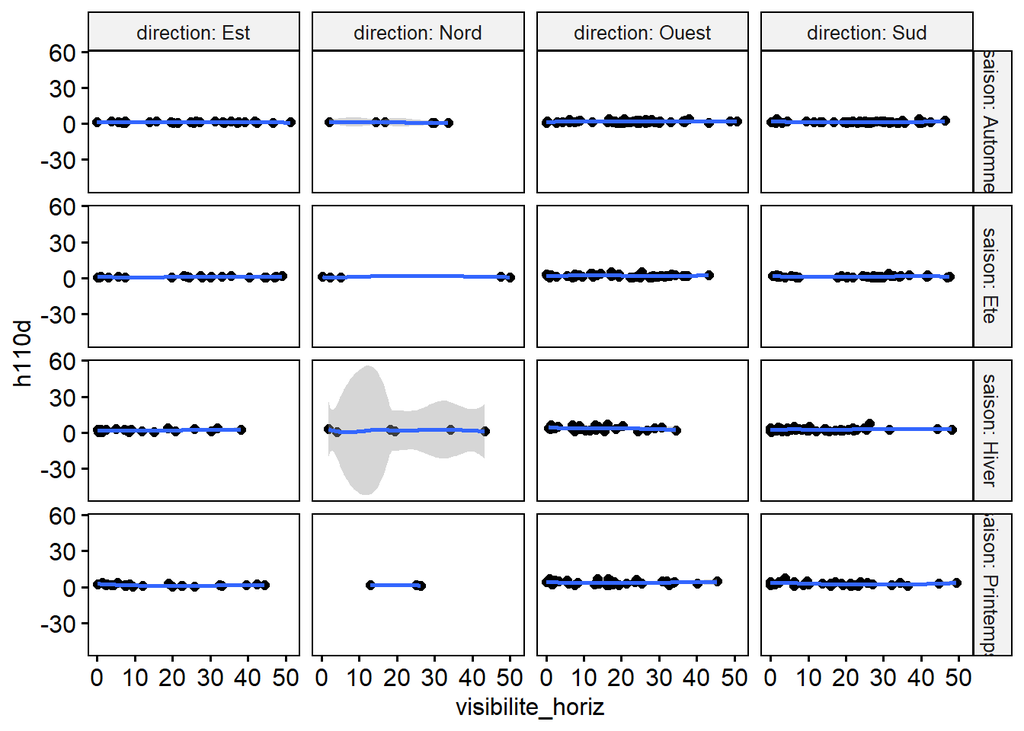

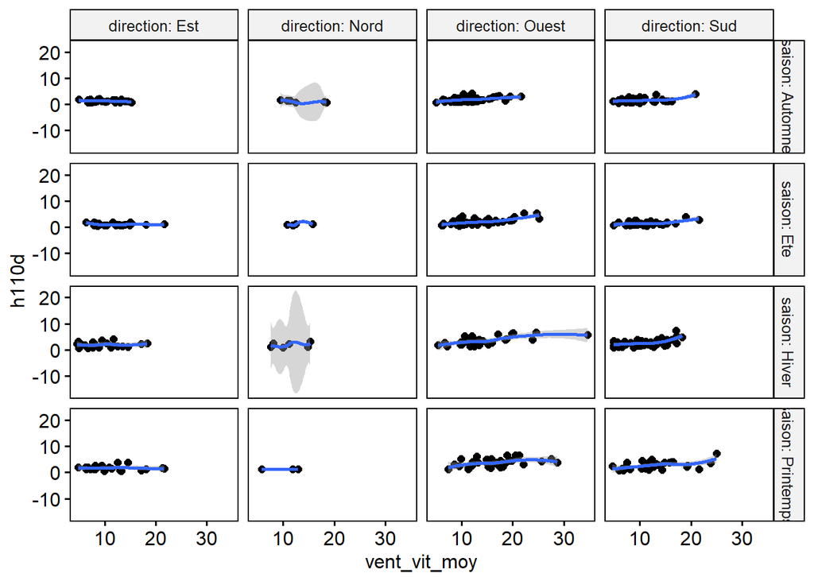

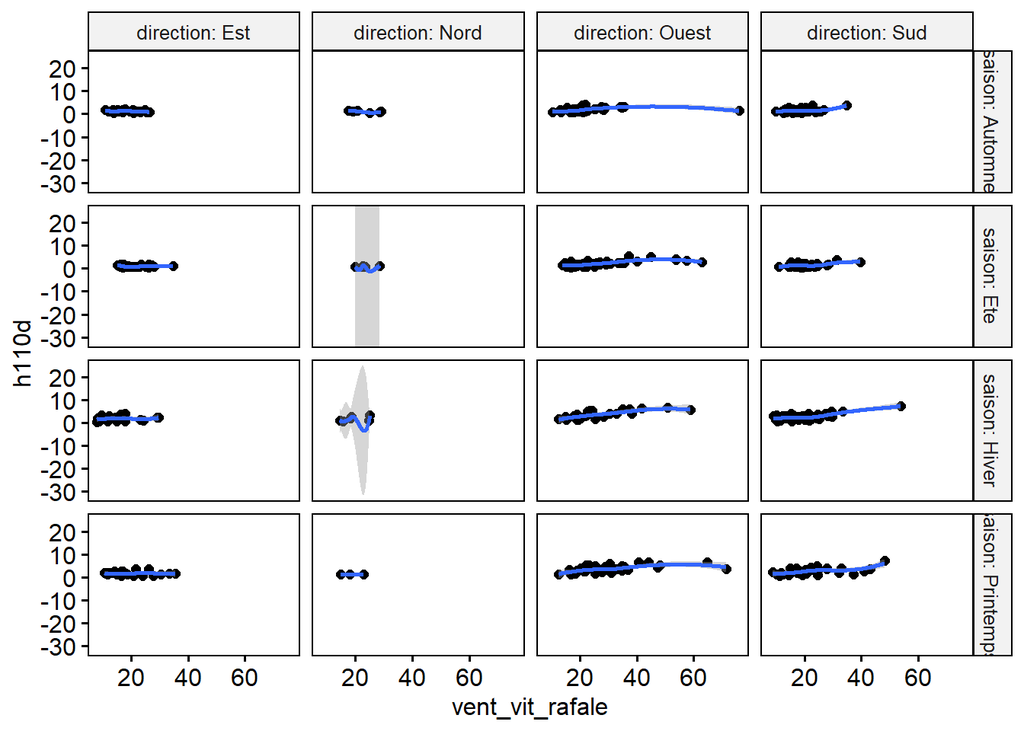

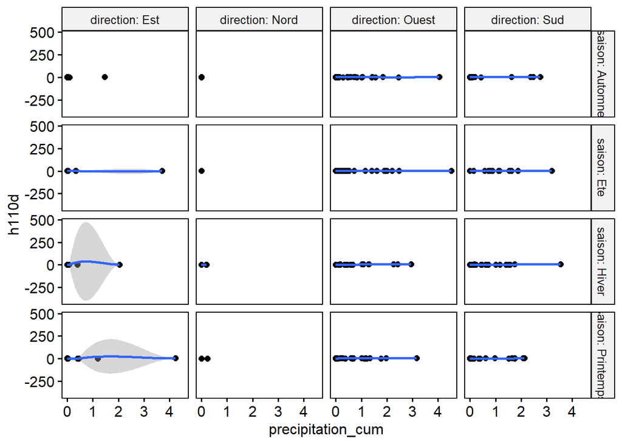

Nous cherchons à savoir s’il existe une intéraction significative entre les covariables et les variables de groupement saison et direction

```r
vagues %>%
  unite(col = "group", saison, direction) %>%
  anova_test( h110d ~ group*temperature+group*pression+group*humidite_relative+group*point2rose+group*precipitation_cum+group*visibilite_horiz+group*vent_vit_moy+group*vent_vit_rafale+group*vent_dir)
```

```
## ANOVA Table (type II tests)
##
##                     Effect DFn DFd      F        p p<.05       ges
## 1                    group  15 313  5.530 5.49e-10     *  2.09e-01
## 2              temperature   1 313  2.509 1.14e-01        8.00e-03
## 3                 pression   1 313  1.249 2.65e-01        4.00e-03
## 4        humidite_relative   1 313  1.905 1.68e-01        6.00e-03
## 5               point2rose   1 313  1.745 1.88e-01        6.00e-03
## 6        precipitation_cum   1 313 -0.812 1.00e+00       -3.00e-03
## 7         visibilite_horiz   1 313  0.025 8.76e-01        7.84e-05
## 8             vent_vit_moy   1 313  0.171 6.80e-01        5.45e-04
## 9          vent_vit_rafale   1 313 14.529 1.66e-04     *  4.40e-02
## 10                vent_dir   1 313  0.334 5.64e-01        1.00e-03
## 11       group:temperature  11 313  1.866 4.30e-02     *  6.20e-02
## 12          group:pression  11 313  1.338 2.02e-01        4.50e-02
## 13 group:humidite_relative  10 313  2.374 1.00e-02     *  7.00e-02
## 14        group:point2rose  10 313  2.393 1.00e-02     *  7.10e-02
## 15 group:precipitation_cum  10 313  2.480 7.00e-03     *  7.30e-02
## 16  group:visibilite_horiz  10 313  0.966 4.73e-01        3.00e-02
## 17      group:vent_vit_moy  10 313  1.336 2.10e-01        4.10e-02
## 18   group:vent_vit_rafale  10 313  2.573 5.00e-03     *  7.60e-02
## 19          group:vent_dir  10 313  1.384 1.87e-01        4.20e-02
```

On voit qu’il existe une intéraction significative avec vent_vit_rafale,precipitation_cum,point2rose,humidite_relative,temperature

## Méthode du Backward

On utilise maintenant la méthode de backward afin de trouver un meilleur modèle

```r
select.variables <- step(model, direction="backward", data=vagues)
```

```
## Start:  AIC=-93.3
## vagues$h110d ~ vagues$temperature + vagues$pression + vagues$humidite_relative +
##     vagues$point2rose + vagues$visibilite_horiz + vagues$vent_vit_moy +
##     vagues$vent_vit_rafale + vagues$vent_dir + vagues$precipitation_cum +
##     vagues$saison * vagues$direction
##
##                                  Df Sum of Sq    RSS     AIC
## - vagues$saison:vagues$direction  9   11.6802 341.84 -95.548
## - vagues$vent_vit_moy             1    0.0002 330.15 -95.297
## - vagues$point2rose               1    0.0181 330.17 -95.273
## - vagues$humidite_relative        1    0.0189 330.17 -95.272
## - vagues$temperature              1    0.1241 330.28 -95.127
## - vagues$visibilite_horiz         1    0.2248 330.38 -94.989
## <none>                                        330.15 -93.298
## - vagues$vent_dir                 1    2.3252 332.48 -92.119
## - vagues$pression                 1    2.9915 333.15 -91.212
## - vagues$precipitation_cum        1    5.3746 335.53 -87.983
## - vagues$vent_vit_rafale          1   19.6566 349.81 -69.100
##
## Step:  AIC=-95.55
## vagues$h110d ~ vagues$temperature + vagues$pression + vagues$humidite_relative +
##     vagues$point2rose + vagues$visibilite_horiz + vagues$vent_vit_moy +
##     vagues$vent_vit_rafale + vagues$vent_dir + vagues$precipitation_cum +
##     vagues$saison + vagues$direction
##
##                            Df Sum of Sq    RSS     AIC
## - vagues$temperature        1    0.0248 341.86 -97.516
## - vagues$vent_vit_moy       1    0.0286 341.86 -97.511
## - vagues$point2rose         1    0.1470 341.98 -97.354
## - vagues$visibilite_horiz   1    0.1716 342.01 -97.321
## - vagues$humidite_relative  1    0.3849 342.22 -97.039
## <none>                                  341.84 -95.548
## - vagues$vent_dir           1    2.2372 344.07 -94.593
## - vagues$pression           1    2.7292 344.56 -93.946
## - vagues$precipitation_cum  1    4.7921 346.63 -91.242
## - vagues$direction          3   10.8456 352.68 -87.399
## - vagues$vent_vit_rafale    1   21.9645 363.80 -69.338
## - vagues$saison             3   29.0907 370.93 -64.550
##
## Step:  AIC=-97.52
```

[output cut: 35 more lines]

```
## Step:  AIC=-101.26
## vagues$h110d ~ vagues$pression + vagues$humidite_relative + vagues$point2rose +
##     vagues$vent_vit_rafale + vagues$vent_dir + vagues$precipitation_cum +
##     vagues$saison + vagues$direction
##
##                            Df Sum of Sq    RSS      AIC
## <none>                                  342.06 -101.256
## - vagues$vent_dir           1     2.148 344.20 -100.420
## - vagues$pression           1     2.693 344.75  -99.704
## - vagues$point2rose         1     3.208 345.26  -99.028
## - vagues$precipitation_cum  1     5.269 347.33  -96.331
## - vagues$humidite_relative  1     6.211 348.27  -95.105
## - vagues$direction          3    10.852 352.91  -93.108
## - vagues$saison             3    30.857 372.91  -68.130
## - vagues$vent_vit_rafale    1    77.638 419.69  -10.594
```

```r
#
summary(select.variables)
```

```
##
## Call:
## lm(formula = vagues$h110d ~ vagues$pression + vagues$humidite_relative +
##     vagues$point2rose + vagues$vent_vit_rafale + vagues$vent_dir +
##     vagues$precipitation_cum + vagues$saison + vagues$direction)
##
## Residuals:
##     Min      1Q  Median      3Q     Max
## -3.8811 -0.5783 -0.0847  0.5072  2.6397
##
## Coefficients:
##                           Estimate Std. Error t value Pr(>|t|)
## (Intercept)              11.322126   6.569787   1.723 0.085525 .
## vagues$pression          -0.011883   0.006385  -1.861 0.063397 .
## vagues$humidite_relative  0.013763   0.004869   2.827 0.004920 **
## vagues$point2rose        -0.025181   0.012396  -2.031 0.042823 *
## vagues$vent_vit_rafale    0.055281   0.005532   9.993  < 2e-16 ***
## vagues$vent_dir           0.001792   0.001078   1.662 0.097189 .
## vagues$precipitation_cum  0.194098   0.074553   2.603 0.009540 **
## vagues$saisonEte         -0.239270   0.114756  -2.085 0.037643 *
## vagues$saisonHiver        0.758626   0.166989   4.543 7.17e-06 ***
## vagues$saisonPrintemps    0.620307   0.168963   3.671 0.000271 ***
## vagues$directionNord     -0.426532   0.236560  -1.803 0.072062 .
## vagues$directionOuest     0.382088   0.210793   1.813 0.070571 .
## vagues$directionSud       0.259225   0.141158   1.836 0.066970 .
## ---
## Signif. codes:  0 '***' 0.001 '**' 0.01 '*' 0.05 '.' 0.1 ' ' 1
##
## Residual standard error: 0.8817 on 440 degrees of freedom
## Multiple R-squared:  0.5556, Adjusted R-squared:  0.5435
## F-statistic: 45.84 on 12 and 440 DF,  p-value: < 2.2e-16
```

Après avoir utiliser la méthode de backward, les variables **temperature**, **visibilité_horiz** et **vent_vit_moy** ont été retirés  
Le R² ajusté est de 0.5435 donc le modèle explique environ 54% de la variabilité de **la hauteur des vagues**  
Ce nouveau modèle a un p-value très faible donc le modèle est significatif  
La majorité des coefficients ont des p-values très significatives car très faibles

## Recherche du meilleur modèle avec la méthode exhaustive à partir du modèle complet

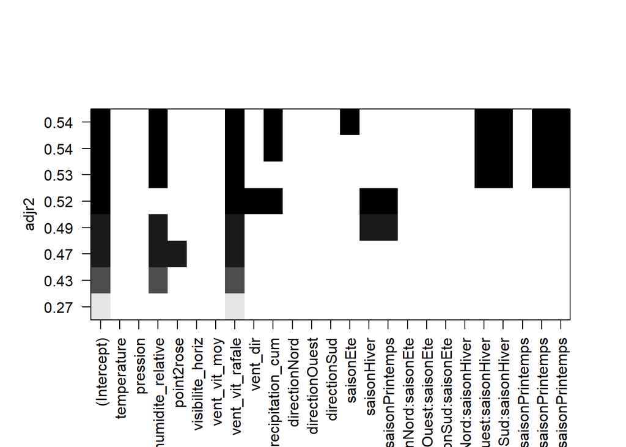

```r
choix <- regsubsets(data=vagues,h110d~temperature+pression+humidite_relative+point2rose+visibilite_horiz+vent_vit_moy+vent_vit_rafale+vent_dir+precipitation_cum+direction*saison,int=T ,method="exh")
resume.choix <- summary(choix)

taille <- as.double(rownames(resume.choix$wh))+1
plot(choix,scale="adjr2")
```

#### Maintenant nous allons tester les hypothèses de validations du modèle

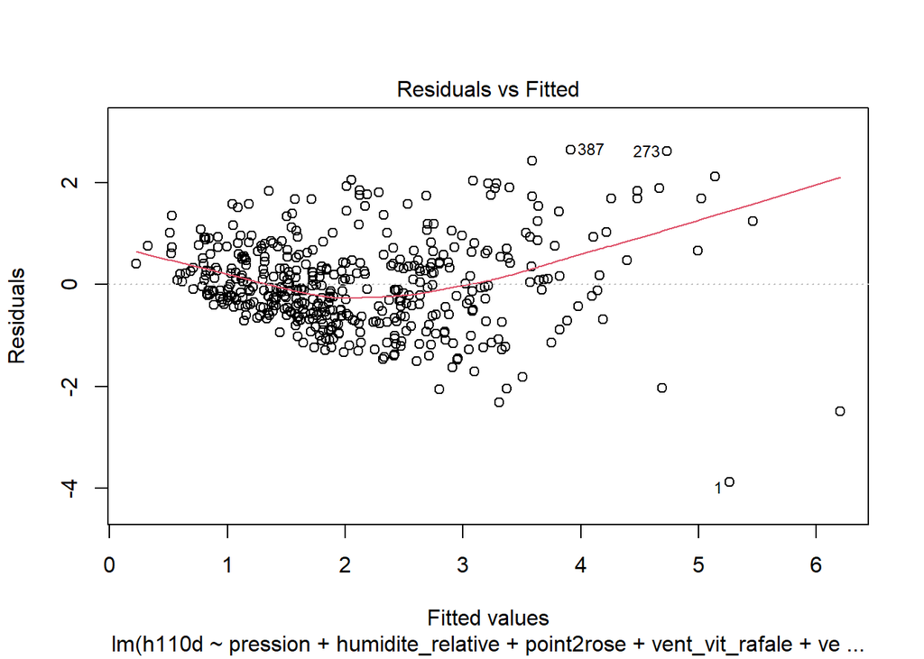

```r
model_backward <- lm(data=vagues,h110d~pression+humidite_relative+point2rose+vent_vit_rafale+vent_dir+precipitation_cum+saison+direction)


plot(model_backward,1)
```

On applique une transformation logarithmique à la variable à expliquer afin de satisfaire cette hypothèse.

```r
model_backward <- lm(data=vagues,log(h110d)~pression+humidite_relative+point2rose+vent_vit_rafale+vent_dir+precipitation_cum+saison+direction)

summary(model_backward)
```

```
##
## Call:
## lm(formula = log(h110d) ~ pression + humidite_relative + point2rose +
##     vent_vit_rafale + vent_dir + precipitation_cum + saison +
##     direction, data = vagues)
##
## Residuals:
##      Min       1Q   Median       3Q      Max
## -1.48582 -0.30646  0.02425  0.28859  0.90894
##
## Coefficients:
##                     Estimate Std. Error t value Pr(>|t|)
## (Intercept)        1.2516215  3.1154919   0.402  0.68807
## pression          -0.0021718  0.0030279  -0.717  0.47360
## humidite_relative  0.0102373  0.0023090   4.434 1.17e-05 ***
## point2rose        -0.0126065  0.0058785  -2.145  0.03254 *
## vent_vit_rafale    0.0214088  0.0026232   8.161 3.52e-15 ***
## vent_dir           0.0011338  0.0005112   2.218  0.02707 *
## precipitation_cum  0.0510001  0.0353543   1.443  0.14986
## saisonEte         -0.1299087  0.0544192  -2.387  0.01740 *
## saisonHiver        0.2623410  0.0791886   3.313  0.00100 ***
## saisonPrintemps    0.2292053  0.0801247   2.861  0.00443 **
## directionNord     -0.2271915  0.1121802  -2.025  0.04345 *
## directionOuest     0.1595152  0.0999612   1.596  0.11126
## directionSud       0.1340589  0.0669391   2.003  0.04582 *
## ---
## Signif. codes:  0 '***' 0.001 '**' 0.01 '*' 0.05 '.' 0.1 ' ' 1
##
## Residual standard error: 0.4181 on 440 degrees of freedom
## Multiple R-squared:  0.5119, Adjusted R-squared:  0.4986
## F-statistic: 38.46 on 12 and 440 DF,  p-value: < 2.2e-16
```

On remarque que le R² ajusté est passé à environ 50%  
Cependant, l’écart type résiduel a diminué de moitié et est de 0.4181

On vérifie à nouveau les hypothèses de validité du modèle

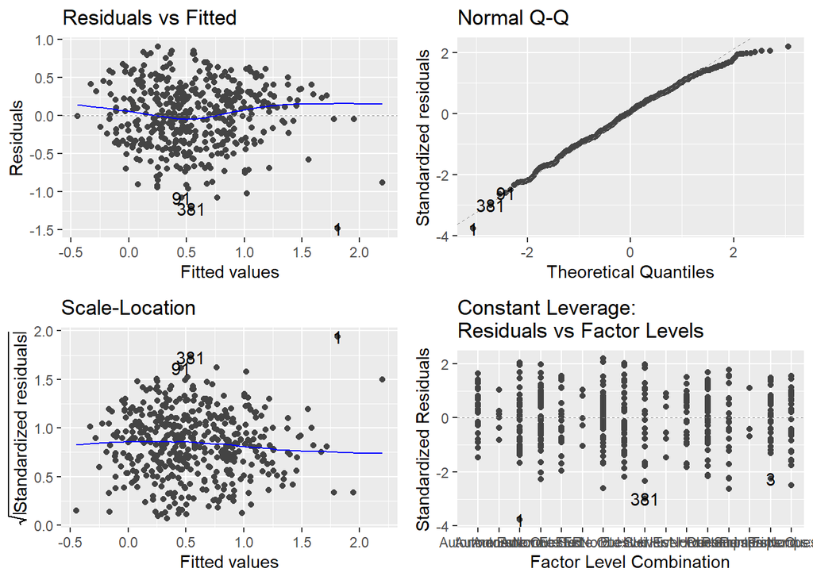

```r
autoplot(model_backward)
```

##### Toutes les hypothèses sont vérifiés !

Ce modèle ayant un R² ajusté et un écart type résiduelle acceptable, on peut retenir ce modèle comme référence pour la partie Compléments.

On crée le modèle complet correspondant à ce modèle afin de faire le test d’emboîtement dans la partie Compléments

```r
model_complet_backward <- lm(data=vagues,log(h110d)~temperature+pression+humidite_relative+point2rose+visibilite_horiz+vent_vit_moy+vent_vit_rafale+vent_dir+precipitation_cum+saison*vagues$direction)
summary(model_complet_backward)
```

```
##
## Call:
## lm(formula = log(h110d) ~ temperature + pression + humidite_relative +
##     point2rose + visibilite_horiz + vent_vit_moy + vent_vit_rafale +
##     vent_dir + precipitation_cum + saison * vagues$direction,
##     data = vagues)
##
## Residuals:
##      Min       1Q   Median       3Q      Max
## -1.23134 -0.28724  0.01181  0.29764  0.91047
##
## Coefficients:
##                                         Estimate Std. Error t value Pr(>|t|)
## (Intercept)                            2.0412031  3.3486723   0.610 0.542479
## temperature                           -0.0381091  0.0452059  -0.843 0.399692
## pression                              -0.0019358  0.0030987  -0.625 0.532494
## humidite_relative                      0.0008457  0.0119278   0.071 0.943508
## point2rose                             0.0271691  0.0474591   0.572 0.567301
## visibilite_horiz                       0.0002294  0.0017068   0.134 0.893125
## vent_vit_moy                           0.0078266  0.0096569   0.810 0.418124
## vent_vit_rafale                        0.0168117  0.0048653   3.455 0.000604
## vent_dir                               0.0011666  0.0005224   2.233 0.026052
## precipitation_cum                      0.0602241  0.0368763   1.633 0.103175
## saisonEte                             -0.3226325  0.1190099  -2.711 0.006979
## saisonHiver                            0.0403323  0.1382869   0.292 0.770691
## saisonPrintemps                        0.0403179  0.1307660   0.308 0.757988
## vagues$directionNord                  -0.3857401  0.1999670  -1.929 0.054389
## vagues$directionOuest                 -0.0733280  0.1327640  -0.552 0.581018
## vagues$directionSud                   -0.0258374  0.1106233  -0.234 0.815437
## saisonEte:vagues$directionNord         0.2494738  0.2848220   0.876 0.381579
## saisonHiver:vagues$directionNord       0.1726695  0.2736243   0.631 0.528347
## saisonPrintemps:vagues$directionNord   0.1925324  0.3256604   0.591 0.554695
## saisonEte:vagues$directionOuest        0.2906254  0.1439712   2.019 0.044148
## saisonHiver:vagues$directionOuest      0.3235859  0.1600815   2.021 0.043862
## saisonPrintemps:vagues$directionOuest  0.3182630  0.1527105   2.084 0.037744
## saisonEte:vagues$directionSud          0.1906416  0.1493443   1.277 0.202463
## saisonHiver:vagues$directionSud        0.2582271  0.1498118   1.724 0.085488
## saisonPrintemps:vagues$directionSud    0.1774236  0.1516604   1.170 0.242703
##
## (Intercept)
```

[output cut: 15 more lines]

```
## saisonEte:vagues$directionNord
## saisonHiver:vagues$directionNord
## saisonPrintemps:vagues$directionNord
## saisonEte:vagues$directionOuest       *
## saisonHiver:vagues$directionOuest     *
## saisonPrintemps:vagues$directionOuest *
## saisonEte:vagues$directionSud
## saisonHiver:vagues$directionSud       .
## saisonPrintemps:vagues$directionSud
## ---
## Signif. codes:  0 '***' 0.001 '**' 0.01 '*' 0.05 '.' 0.1 ' ' 1
##
## Residual standard error: 0.4199 on 428 degrees of freedom
## Multiple R-squared:  0.5212, Adjusted R-squared:  0.4944
## F-statistic: 19.41 on 24 and 428 DF,  p-value: < 2.2e-16
```

# Tentative d’amélioration de notre modèle

#### Toutefois, on souhaite tenter d’améliorer ce modèle en effectuant certaines modifications sur nos données et notre modèle

Pour cela, on effectue une recherche exhaustive des modèles possibles puis on cherche le modèle ayant le plus grand R² ajusté

```r
model_ameliore <- regsubsets(h110d~temperature+pression+humidite_relative+point2rose+visibilite_horiz+vent_vit_moy+vent_vit_rafale+vent_dir+precipitation_cum+saison*direction,data=vagues,
                             nbest = 1,       # 1 seul meilleur pour chaque nombre de variables
                             nvmax = NULL,    # NULL pas de limites pour le
                             force.in = NULL,  # pas de variables à inclure de force
                             force.out = NULL,  # pas de variables à exclure de force.
                             method = "exhaustive")  #


summary(model_ameliore)
```

On affiche le graphique permettant de voir à peu près quelle est la valeur maximale du R² ajusté qu’un de nos modèles trouvés a atteint

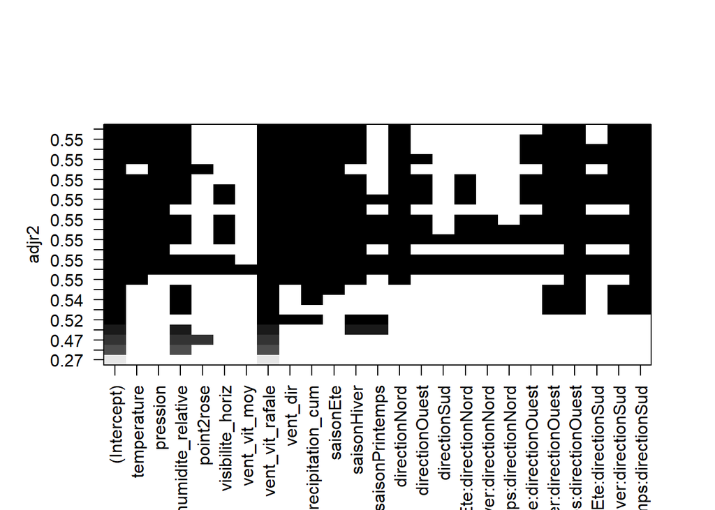

```r
plot(model_ameliore,scale="adjr2")
```

On remarque que le R² ajusté maximale est d’environ 0.55  
On cherche à récupérer le modèle correspondant

```r
summary.out <- summary(model_ameliore)

summary.out$which[which.max(summary.out$adjr2),]
```

```
##                    (Intercept)                    temperature
##                           TRUE                           TRUE
##                       pression              humidite_relative
##                           TRUE                           TRUE
##                     point2rose               visibilite_horiz
##                          FALSE                          FALSE
##                   vent_vit_moy                vent_vit_rafale
##                          FALSE                           TRUE
##                       vent_dir              precipitation_cum
##                           TRUE                           TRUE
##                      saisonEte                    saisonHiver
##                           TRUE                           TRUE
##                saisonPrintemps                  directionNord
##                          FALSE                           TRUE
##                 directionOuest                   directionSud
##                          FALSE                          FALSE
##        saisonEte:directionNord      saisonHiver:directionNord
##                          FALSE                          FALSE
##  saisonPrintemps:directionNord       saisonEte:directionOuest
##                          FALSE                          FALSE
##     saisonHiver:directionOuest saisonPrintemps:directionOuest
##                           TRUE                           TRUE
##         saisonEte:directionSud       saisonHiver:directionSud
##                          FALSE                           TRUE
##   saisonPrintemps:directionSud
##                           TRUE
```

Cette sortie nous permet de savoir quelles sont les variables présentent dans le modèle ayant le plus grand R² ajusté

### Construction du modèle amélioré

```r
model_ameliore <- lm(data=vagues,h110d~1+humidite_relative+precipitation_cum+printemps:ouest+printemps:sud+temperature+vent_vit_rafale+ete+nord+vent_dir+hiver+hiver:ouest+hiver:sud)
summary(model_ameliore)
```

```
##
## Call:
## lm(formula = h110d ~ 1 + humidite_relative + precipitation_cum +
##     printemps:ouest + printemps:sud + temperature + vent_vit_rafale +
##     ete + nord + vent_dir + hiver + hiver:ouest + hiver:sud,
##     data = vagues)
##
## Residuals:
##     Min      1Q  Median      3Q     Max
## -3.7375 -0.5519 -0.0510  0.4771  2.7375
##
## Coefficients:
##                     Estimate Std. Error t value Pr(>|t|)
## (Intercept)       -0.0645837  0.4260926  -0.152 0.879594
## humidite_relative  0.0090205  0.0048294   1.868 0.062449 .
## precipitation_cum  0.2494765  0.0702195   3.553 0.000422 ***
## temperature       -0.0225895  0.0100644  -2.244 0.025297 *
## vent_vit_rafale    0.0542947  0.0052599  10.322  < 2e-16 ***
## ete               -0.2399390  0.1083793  -2.214 0.027349 *
## nord              -0.4683431  0.2106424  -2.223 0.026696 *
## vent_dir           0.0018083  0.0006911   2.617 0.009188 **
## hiver              0.3191484  0.2127861   1.500 0.134369
## printemps:ouest    0.9874979  0.2038815   4.843 1.77e-06 ***
## printemps:sud      0.5922768  0.1887213   3.138 0.001813 **
## ouest:hiver        0.7197237  0.2612841   2.755 0.006121 **
## sud:hiver          0.4009805  0.2168763   1.849 0.065144 .
## ---
## Signif. codes:  0 '***' 0.001 '**' 0.01 '*' 0.05 '.' 0.1 ' ' 1
##
## Residual standard error: 0.8733 on 440 degrees of freedom
## Multiple R-squared:  0.564,  Adjusted R-squared:  0.5521
## F-statistic: 47.42 on 12 and 440 DF,  p-value: < 2.2e-16
```

### Vérification des hypothèses de validité du modèle

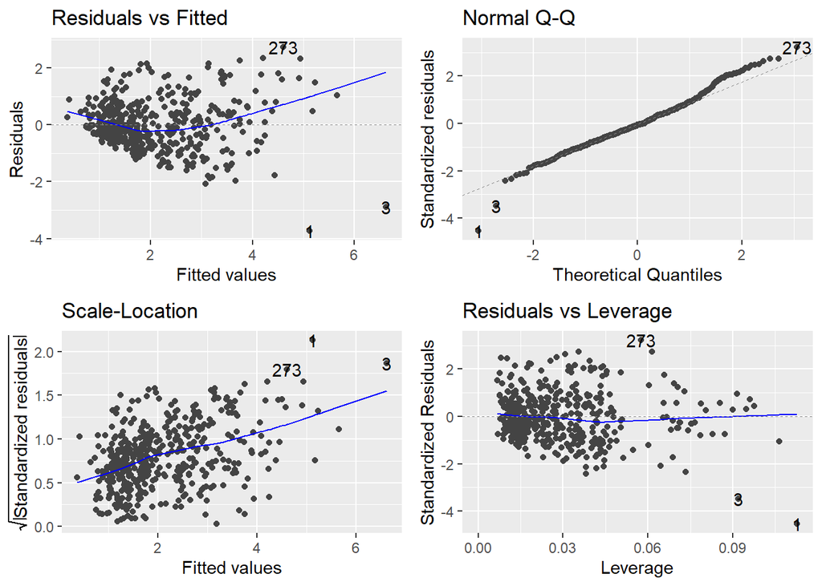

```r
autoplot(model_ameliore)
```

On constate que l’hypothèse d’homoscédasticité n’est pas vérifiée  
On effectue une transformation logorithmique

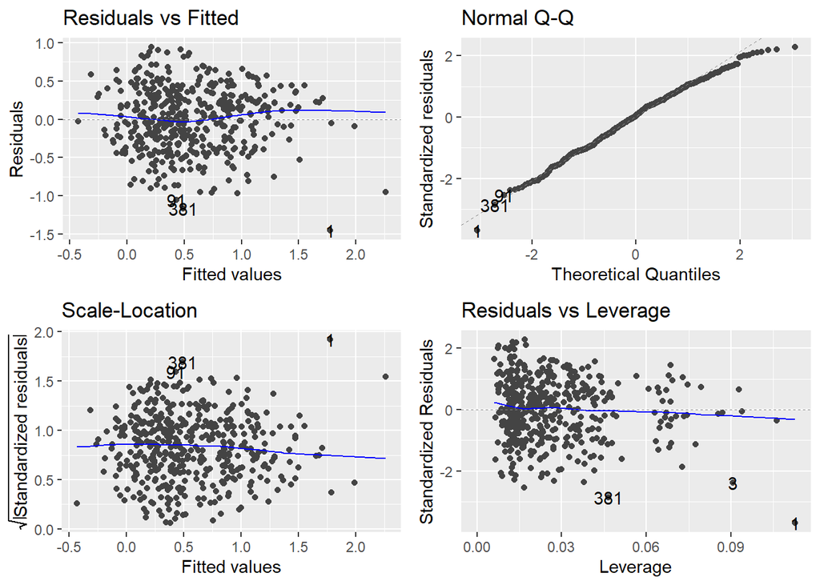

```r
model_ameliore <- lm(data=vagues,log(h110d)~1+humidite_relative+precipitation_cum+printemps:ouest+printemps:sud+temperature+vent_vit_rafale+ete+nord+vent_dir+hiver:ouest+hiver:sud)

autoplot(model_ameliore)
```

Après transformation, on voit que toutes les hypothèses de validité du modèle sont vérifiées

```r
summary(model_ameliore)
```

```
##
## Call:
## lm(formula = log(h110d) ~ 1 + humidite_relative + precipitation_cum +
##     printemps:ouest + printemps:sud + temperature + vent_vit_rafale +
##     ete + nord + vent_dir + hiver:ouest + hiver:sud, data = vagues)
##
## Residuals:
##      Min       1Q   Median       3Q      Max
## -1.45385 -0.28216  0.01738  0.29374  0.94531
##
## Coefficients:
##                     Estimate Std. Error t value Pr(>|t|)
## (Intercept)       -0.5731044  0.2036506  -2.814 0.005109 **
## humidite_relative  0.0080320  0.0021944   3.660 0.000282 ***
## precipitation_cum  0.0566941  0.0330045   1.718 0.086541 .
## temperature       -0.0149112  0.0046350  -3.217 0.001390 **
## vent_vit_rafale    0.0211874  0.0025141   8.428 5.04e-16 ***
## ete               -0.1463276  0.0514124  -2.846 0.004631 **
## nord              -0.2542548  0.0989508  -2.570 0.010512 *
## vent_dir           0.0012706  0.0003207   3.962 8.68e-05 ***
## printemps:ouest    0.2608153  0.0948225   2.751 0.006194 **
## printemps:sud      0.1869615  0.0861563   2.170 0.030538 *
## ouest:hiver        0.2637366  0.0968725   2.723 0.006736 **
## sud:hiver          0.2555025  0.0754957   3.384 0.000777 ***
## ---
## Signif. codes:  0 '***' 0.001 '**' 0.01 '*' 0.05 '.' 0.1 ' ' 1
##
## Residual standard error: 0.4174 on 441 degrees of freedom
## Multiple R-squared:  0.5124, Adjusted R-squared:  0.5002
## F-statistic: 42.13 on 11 and 441 DF,  p-value: < 2.2e-16
```

#### On cherche à vérifier la présence de points aberrants en utilisant la distance de Cook

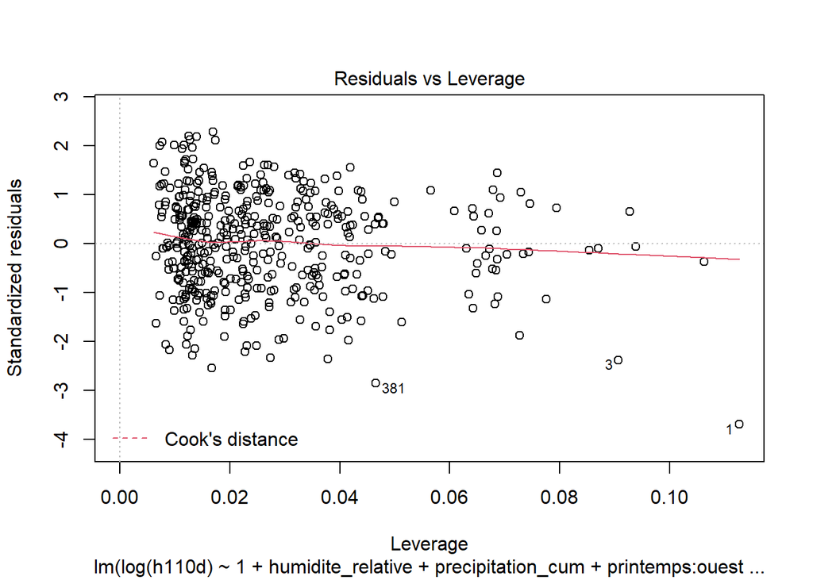

```r
plot(model_ameliore,5)
```

On enleve le point aberrant 1 en utilisant la distance de Cook comme réference

On supprime la 1ere ligne

```r
vagues <- slice(vagues,2:453)
model_ameliore <- lm(data=vagues,log(h110d)~1+humidite_relative+precipitation_cum+printemps:ouest+printemps:sud+temperature+vent_vit_rafale+ete+nord+vent_dir+hiver:ouest+hiver:sud)

summary(model_ameliore)
```

```
##
## Call:
## lm(formula = log(h110d) ~ 1 + humidite_relative + precipitation_cum +
##     printemps:ouest + printemps:sud + temperature + vent_vit_rafale +
##     ete + nord + vent_dir + hiver:ouest + hiver:sud, data = vagues)
##
## Residuals:
##     Min      1Q  Median      3Q     Max
## -1.1439 -0.2746  0.0131  0.2963  0.9604
##
## Coefficients:
##                     Estimate Std. Error t value Pr(>|t|)
## (Intercept)       -0.6848652  0.2028958  -3.375 0.000802 ***
## humidite_relative  0.0086967  0.0021698   4.008 7.19e-05 ***
## precipitation_cum  0.0484388  0.0326002   1.486 0.138036
## temperature       -0.0139248  0.0045754  -3.043 0.002479 **
## vent_vit_rafale    0.0242481  0.0026085   9.296  < 2e-16 ***
## ete               -0.1631978  0.0508659  -3.208 0.001432 **
## nord              -0.2619720  0.0975374  -2.686 0.007508 **
## vent_dir           0.0012656  0.0003161   4.004 7.30e-05 ***
## printemps:ouest    0.2211051  0.0940448   2.351 0.019160 *
## printemps:sud      0.1720215  0.0850001   2.024 0.043597 *
## ouest:hiver        0.2344134  0.0957870   2.447 0.014786 *
## sud:hiver          0.2458993  0.0744448   3.303 0.001034 **
## ---
## Signif. codes:  0 '***' 0.001 '**' 0.01 '*' 0.05 '.' 0.1 ' ' 1
##
## Residual standard error: 0.4114 on 440 degrees of freedom
## Multiple R-squared:  0.5273, Adjusted R-squared:  0.5155
## F-statistic: 44.63 on 11 and 440 DF,  p-value: < 2.2e-16
```

Le choix de supprimer ce poids aberrant nous a permis d’améliorer notre R² ajusté  
Cependant, la p-valeur associée à la variable **precipitation-cum** n’est plus significatif.  
On décide d’enlever cette variable de notre modèle

```r
model_ameliore <- lm(data=vagues,log(h110d)~1+humidite_relative+printemps:ouest+printemps:sud+temperature+vent_vit_rafale+ete+nord+vent_dir+hiver:ouest+hiver:sud)
summary(model_ameliore)
```

```
##
## Call:
## lm(formula = log(h110d) ~ 1 + humidite_relative + printemps:ouest +
##     printemps:sud + temperature + vent_vit_rafale + ete + nord +
##     vent_dir + hiver:ouest + hiver:sud, data = vagues)
##
## Residuals:
##      Min       1Q   Median       3Q      Max
## -1.17387 -0.27564  0.02425  0.29464  0.95633
##
## Coefficients:
##                     Estimate Std. Error t value Pr(>|t|)
## (Intercept)       -0.7937312  0.1894635  -4.189 3.38e-05 ***
## humidite_relative  0.0099732  0.0019952   4.999 8.34e-07 ***
## temperature       -0.0138874  0.0045816  -3.031  0.00258 **
## vent_vit_rafale    0.0257829  0.0023985  10.750  < 2e-16 ***
## ete               -0.1549502  0.0506313  -3.060  0.00235 **
## nord              -0.2713104  0.0974679  -2.784  0.00561 **
## vent_dir           0.0012523  0.0003164   3.958 8.80e-05 ***
## printemps:ouest    0.2078938  0.0937517   2.217  0.02710 *
## printemps:sud      0.1664695  0.0850342   1.958  0.05090 .
## ouest:hiver        0.2264835  0.0957691   2.365  0.01847 *
## sud:hiver          0.2375523  0.0743341   3.196  0.00149 **
## ---
## Signif. codes:  0 '***' 0.001 '**' 0.01 '*' 0.05 '.' 0.1 ' ' 1
##
## Residual standard error: 0.4119 on 441 degrees of freedom
## Multiple R-squared:  0.525,  Adjusted R-squared:  0.5142
## F-statistic: 48.74 on 10 and 441 DF,  p-value: < 2.2e-16
```

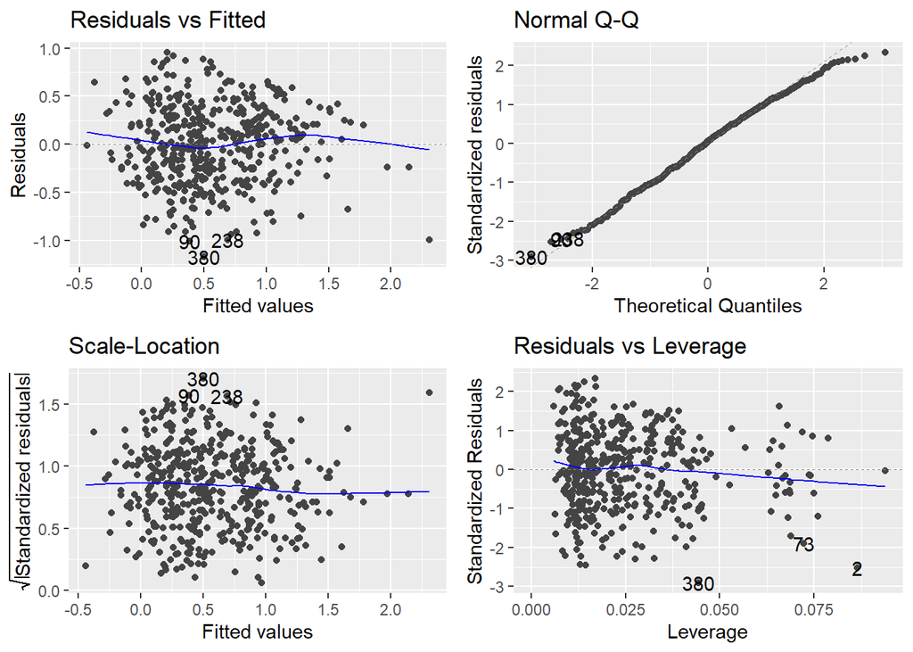

```r
autoplot(model_ameliore)
```

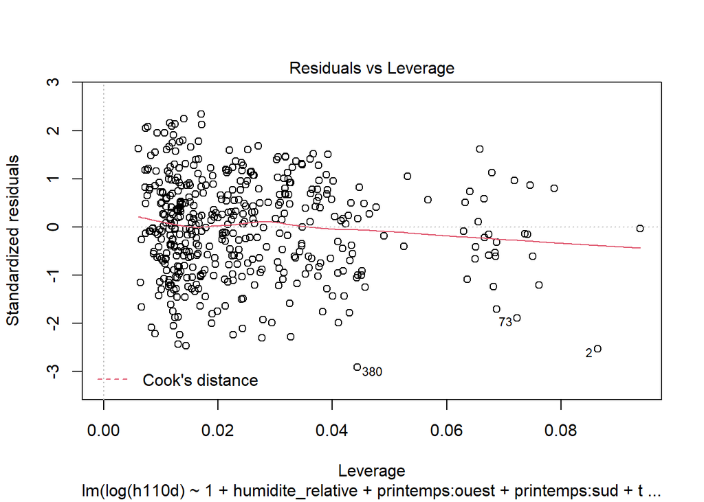

```r
plot(model_ameliore,5)
```

```r
vagues <- vagues[-380,]

model_ameliore <- lm(data=vagues,log(h110d)~1+humidite_relative+printemps:ouest+printemps:sud+temperature+vent_vit_rafale+ete+nord+vent_dir+hiver:ouest+hiver:sud)
summary(model_ameliore)
```

```
##
## Call:
## lm(formula = log(h110d) ~ 1 + humidite_relative + printemps:ouest +
##     printemps:sud + temperature + vent_vit_rafale + ete + nord +
##     vent_dir + hiver:ouest + hiver:sud, data = vagues)
##
## Residuals:
##      Min       1Q   Median       3Q      Max
## -1.01462 -0.28011  0.02804  0.29356  0.96642
##
## Coefficients:
##                     Estimate Std. Error t value Pr(>|t|)
## (Intercept)       -0.7734791  0.1879688  -4.115 4.62e-05 ***
## humidite_relative  0.0103893  0.0019832   5.239 2.51e-07 ***
## temperature       -0.0154278  0.0045725  -3.374 0.000806 ***
## vent_vit_rafale    0.0254011  0.0023815  10.666  < 2e-16 ***
## ete               -0.1547991  0.0501981  -3.084 0.002173 **
## nord              -0.2785486  0.0966653  -2.882 0.004150 **
## vent_dir           0.0011927  0.0003143   3.794 0.000169 ***
## printemps:ouest    0.1935384  0.0930777   2.079 0.038166 *
## printemps:sud      0.1465286  0.0845790   1.732 0.083895 .
## ouest:hiver        0.2108747  0.0950980   2.217 0.027103 *
## sud:hiver          0.2143936  0.0741179   2.893 0.004010 **
## ---
## Signif. codes:  0 '***' 0.001 '**' 0.01 '*' 0.05 '.' 0.1 ' ' 1
##
## Residual standard error: 0.4084 on 440 degrees of freedom
## Multiple R-squared:  0.5295, Adjusted R-squared:  0.5188
## F-statistic: 49.53 on 10 and 440 DF,  p-value: < 2.2e-16
```

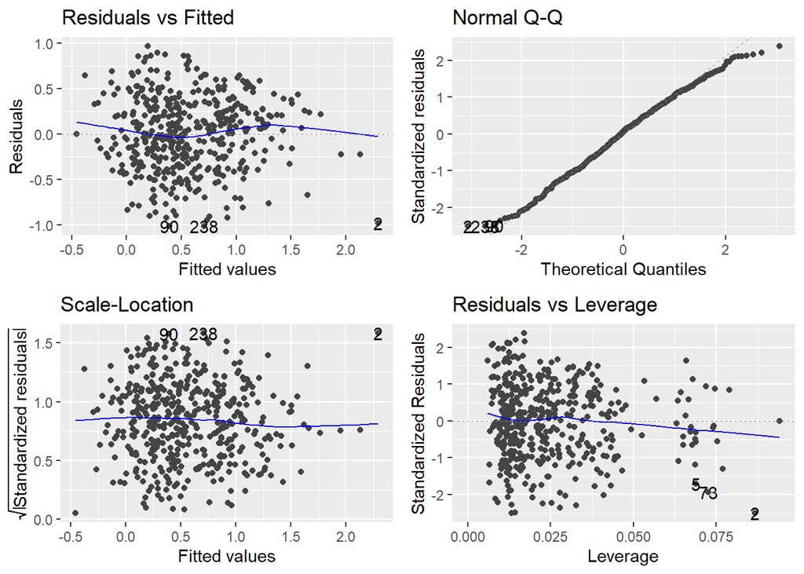

```r
autoplot(model_ameliore)
```

#### On vérifie une dernière fois s’il existe un meilleur modèle que le notre à partir des mêmes variables de départ et en utilisant la méthode exhaustive

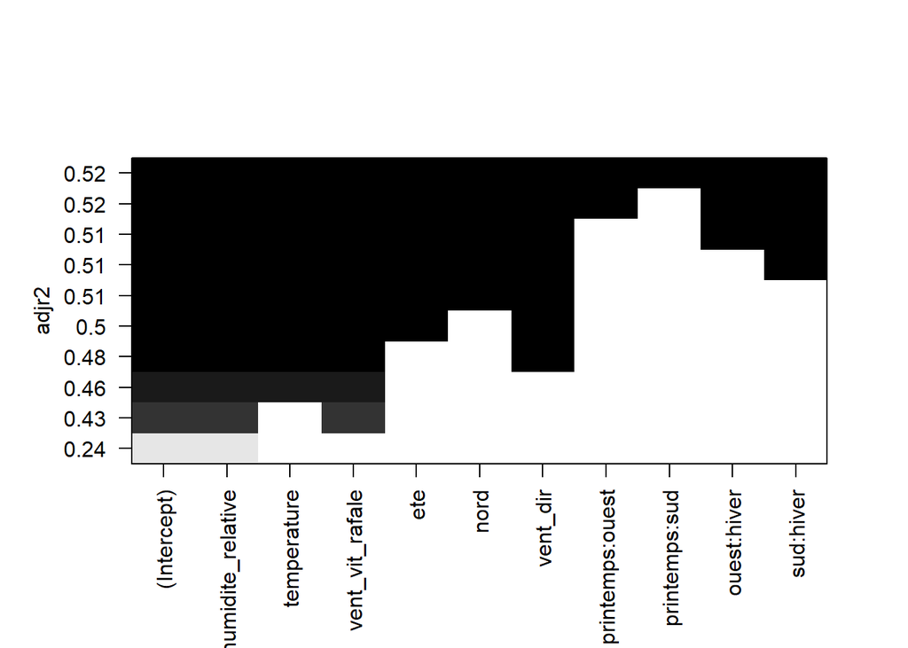

```r
model_ameliore2 <- regsubsets(log(h110d)~1+humidite_relative+printemps:ouest+printemps:sud+temperature+vent_vit_rafale+ete+nord+vent_dir+hiver:ouest+hiver:sud,data=vagues,
                              nbest = 1,       # 1 seul meilleur pour chaque nombre de variables
                              nvmax = NULL,    # NULL pas de limites pour le
                              force.in = NULL,  # pas de variables à inclure de force
                              force.out = NULL,  # pas de variables à exclure de force.
                              method = "exhaustive")
plot(model_ameliore2,scale="adjr2")
```

```r
summary.out <- summary(model_ameliore2)


summary.out$which[which.max(summary.out$adjr2),]
```

```
##       (Intercept) humidite_relative       temperature   vent_vit_rafale
##              TRUE              TRUE              TRUE              TRUE
##               ete              nord          vent_dir   printemps:ouest
##              TRUE              TRUE              TRUE              TRUE
##     printemps:sud       ouest:hiver         sud:hiver
##              TRUE              TRUE              TRUE
```

### On a confirmé le fait que l’on ne peut obtenir un modèle emboîté meilleur que ce modèle, on garde donc ce modèle pour modèliser la hauteur des vagues

# Prédiction de notre modèle amélioré et du modèle backward

En premier lieu, nous allons construire un dataframe regroupant les données de base et les données prédites avec notre modèle amélioré puis comparé leur distribution

```
##   Y  dataset type
## 1 1 6.702083 Base
## 2 2 3.712353 Base
## 3 3 3.830000 Base
## 4 4 4.024167 Base
## 5 5 2.663333 Base
## 6 6 3.513333 Base
```

Après avoir crée notre tableau de donnée *vagues_enchantillon*, nous pouvons afficher la courbe de densité de notre prédiction.

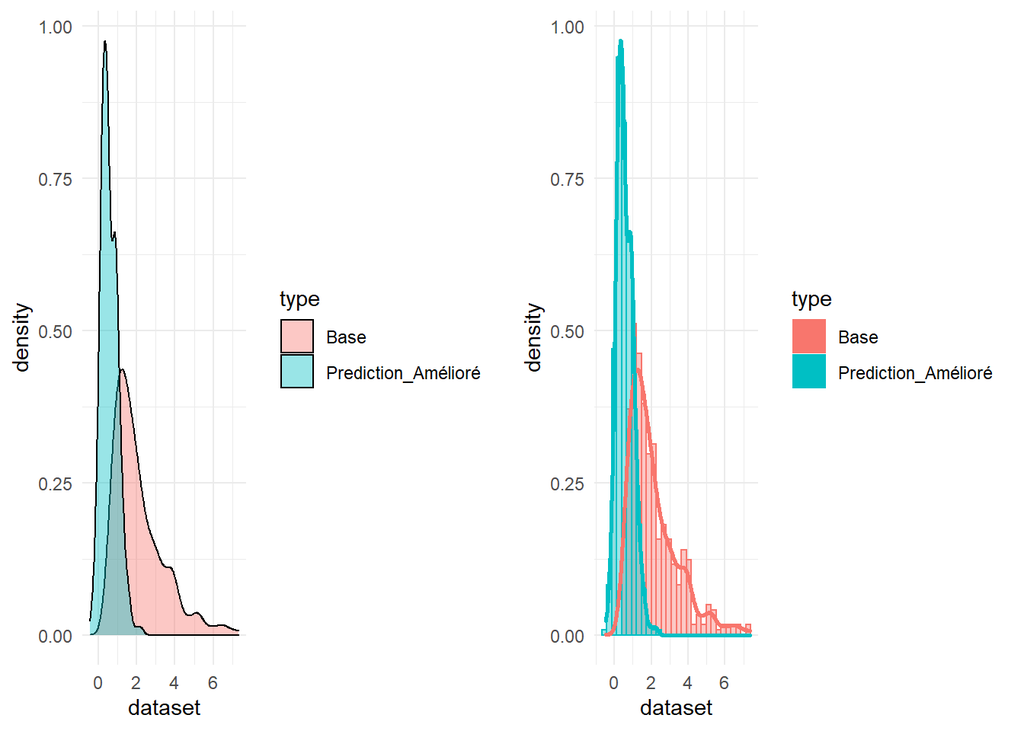

Notre densité ressemble pas à la courbe de densité des données terrains.

Maintenant, on affiche la courbe de densité du modèle backward.

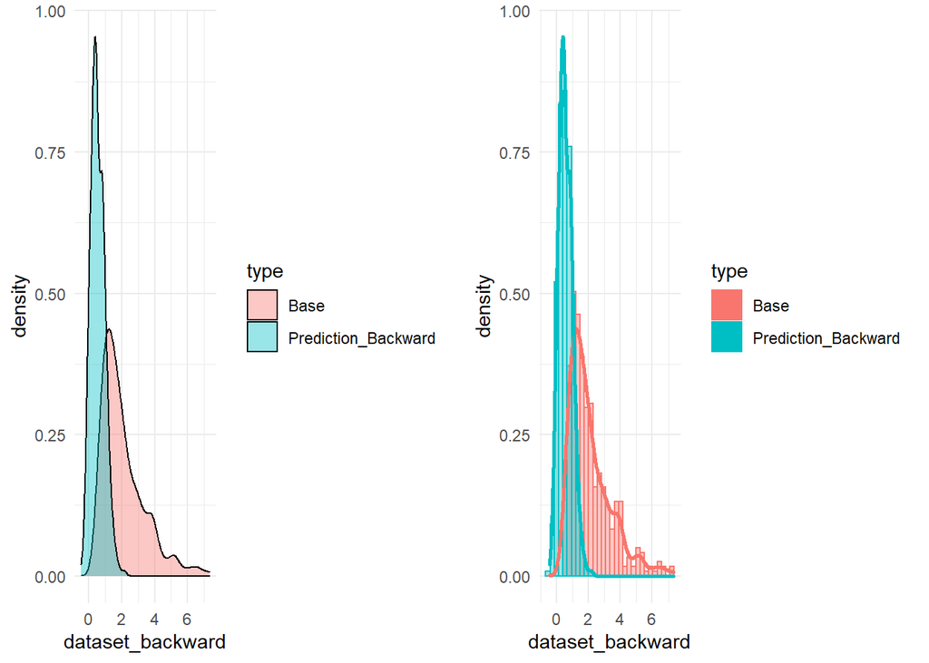

La courbe de densité des prédictions du modèle backward ressemble fortement à celle du modèle amélioré  
Nous allons superposer les trois densités pour mieux visualiser cela

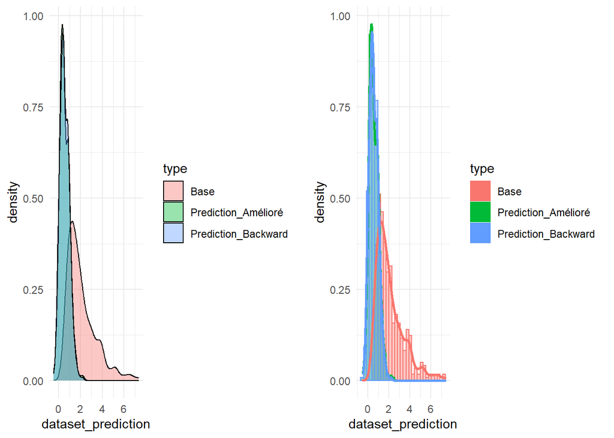

On remarque que les distributions des prédictions de nos deux modèles sont presque identitiques.  
Les deux modèles n’ont pas un pouvoir de prédiction élevé  
On peut expliquer cela par leur R² ajusté qui est moyen.  
Notre but n’est pas de prédire les observations d’entraînement mais plutôt de visualiser les données prédites par nos deux modèles et les comparer aux données terrains.

On ne peut pas prédire des données qui nous ont permis de construire nos modèles Il serait intéressant d’avoir des données supplémentaires pour mettre à l’épreuve la prévision de nos modèles

Ce projet nous a permis d’explorer toutes les notions vues en cours et tds, nous avons du raisonner longuement sur une stratégie afin de trouver le meilleur modèle expliquant la hauteur des vagues  
Cela nous a poussé à effectuer de nombreuses recherches et a enrichi nos connaissances sur les modèles de régressions et les tests d’hypothèses

# Annexe

### Données utilisées pour la partie Compléments question 6

#### Test d’adéquation à la loi normale des 20 premiers résidus

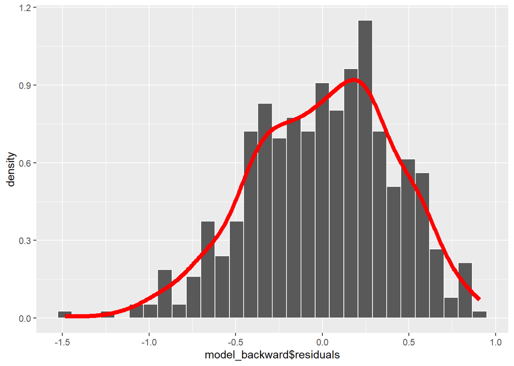

```r
residus_20 <- as.data.frame(model_backward$residuals[1:20])
residus_20sort <- arrange(residus_20,desc(residus_20))
var_residus_20 <- var(residus_20)
image_residus = pnorm(as.double(unlist(residus_20sort[1]),mean=0,sd = sqrt(var_residus_20)))

matrice_residus <- cbind(residus_20sort,image_residus)
n=20
kolmogov_a <- rep('NA',n)
kolmogov_b <- rep('NA',n)
kolmogov_max <- rep('NA',n)
for(i in 1:n){
  kolmogov_a[i] = abs(matrice_residus$image_residus[i] - (i/n))
  kolmogov_b[i] = abs(matrice_residus$image_residus[i] - (i-1)/n)
  kolmogov_max[i] = max(kolmogov_a[i],kolmogov_b[i])
}
max_col_kolmogov <- max(kolmogov_max)

matrice_residus <- mutate(matrice_residus,kolmogov_a)
matrice_residus <- mutate(matrice_residus,kolmogov_b)
matrice_residus <- mutate(matrice_residus,kolmogov_max)
colnames(matrice_residus)[1] = 'Résidus'
hist_res <- ggplot(model_backward,aes(x =model_backward$residuals,y=..density.. ))+
  geom_histogram(col='white',bins = 30) +
  stat_density(geom="line",colour='red',size=2,position = 'identity')


hist_res
```